# EDA_Project

Lets take a look at some other relationships we identified earlier.

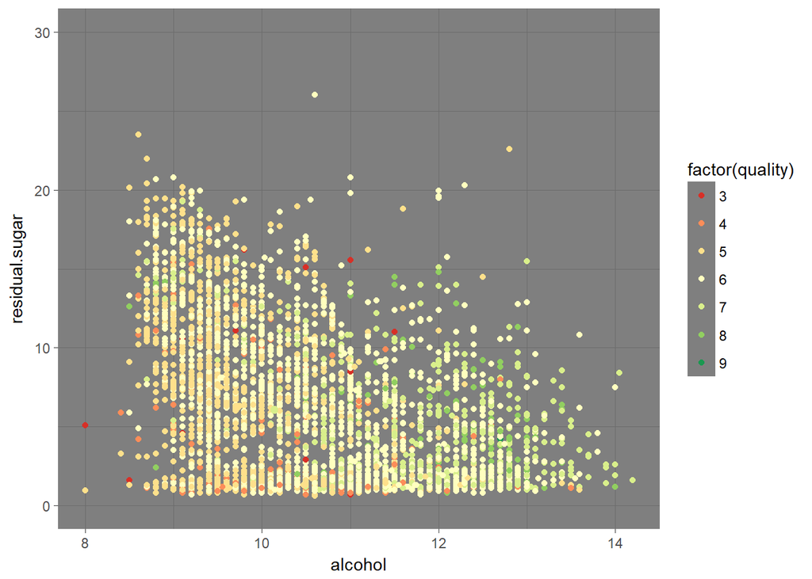

Again just a higher chance for a higher quality as the alcohol increases. It doesn’t look like the residual sugar plays into it much at all.

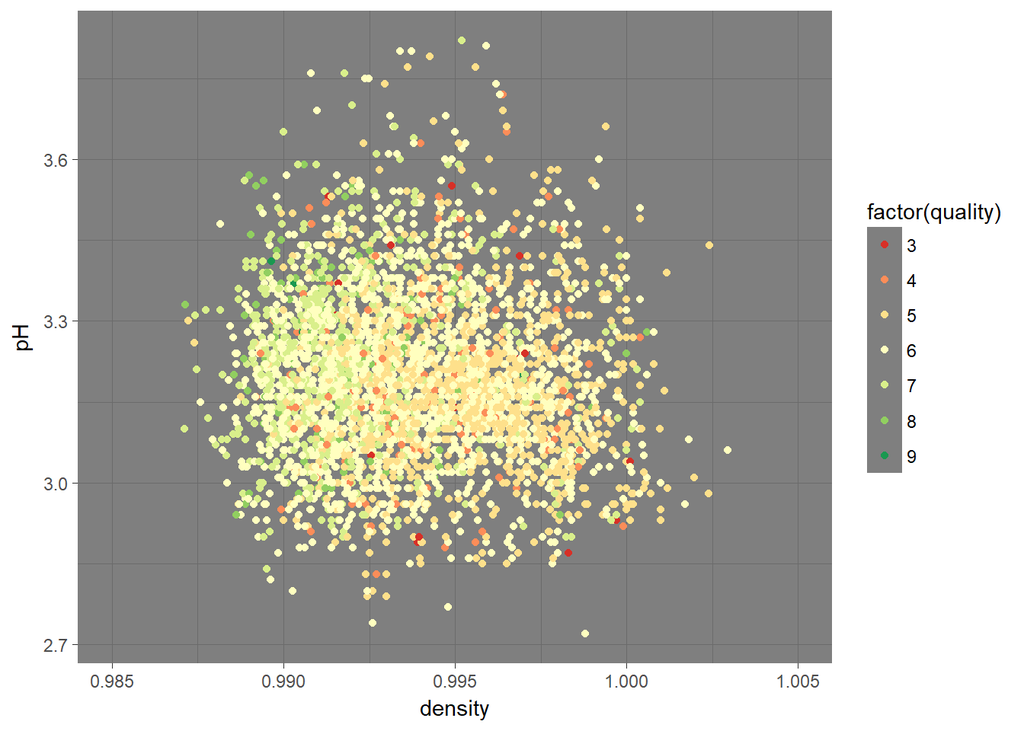

There is no real discinction here, possibly a slightly higher chance for high quality at a lower density. But apparently pH doesn’t matter at all.

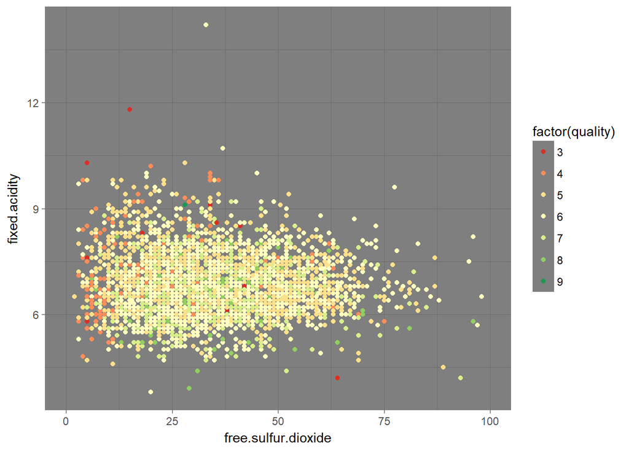

It looks like there might be a trend towards lower fixed acidity. I wonder about a combination of fixed and volatile acidity when combined with alcohol.

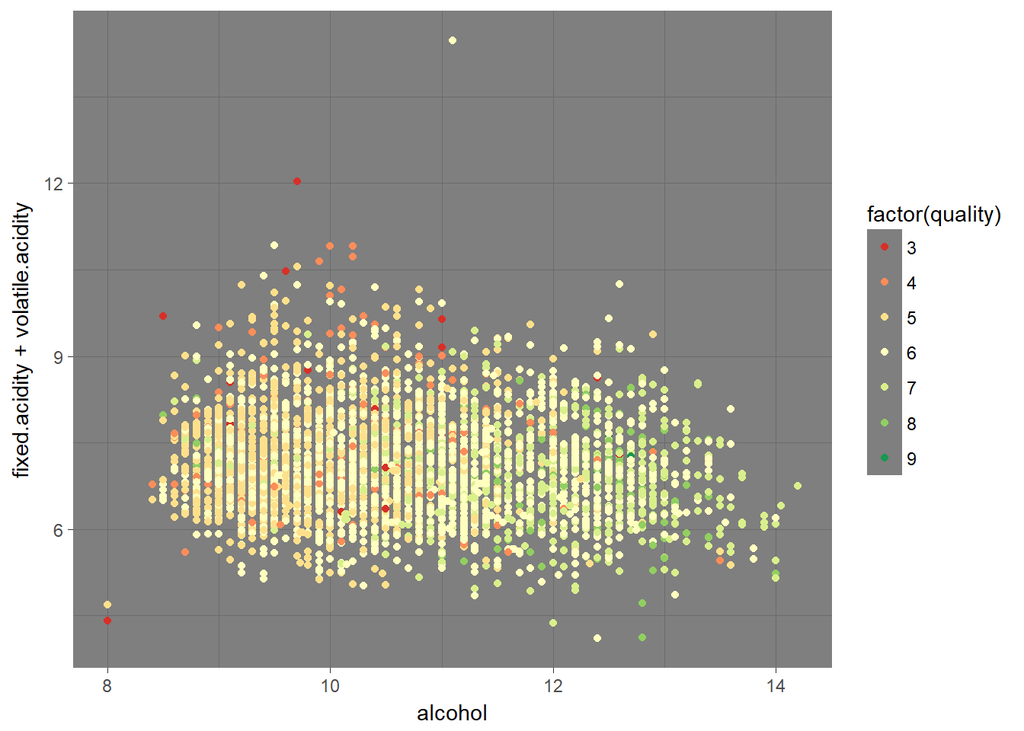

Doesn’t really appear to be any different than just alcohol content. There might be a slight trend towards lower acidity.

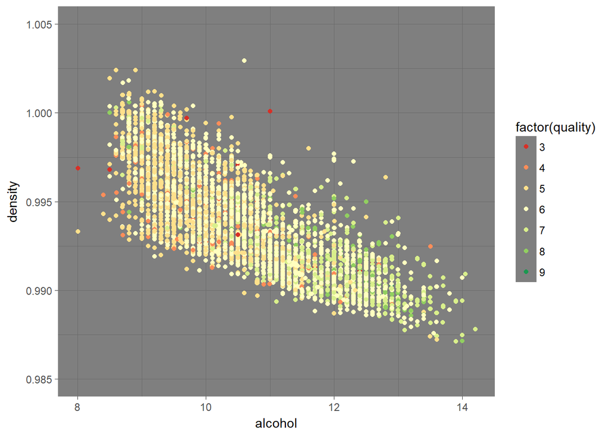

These last two plots are really the only ones that I have tried that seems to indicate any sort of corelation between any of the variables and the quality and it is very weak. The quality is only slightly squewed towards higher alcohol and lower density or lower acidity.

Lets see if a linear model can make any predictions.

```
##
## Calls:
## m1: lm(formula = quality ~ alcohol, data = wqw)
## m2: lm(formula = quality ~ alcohol + density, data = wqw)
## m5: lm(formula = quality ~ alcohol + density + residual.sugar + chlorides +
##     sulphates, data = wqw)
## m7: lm(formula = quality ~ alcohol + density + residual.sugar + chlorides +
##     sulphates + pH + fixed.acidity + volatile.acidity, data = wqw)
## m9: lm(formula = quality ~ alcohol + density + residual.sugar + chlorides +
##     sulphates + pH + fixed.acidity + volatile.acidity + citric.acid +
##     free.sulfur.dioxide, data = wqw)
## m10: lm(formula = quality ~ alcohol + density + residual.sugar + chlorides +
##     sulphates + pH + fixed.acidity + volatile.acidity + citric.acid +
##     free.sulfur.dioxide + total.sulfur.dioxide, data = wqw)
##
## ============================================================================================================
##                              m1            m2            m5            m7            m9           m10
## ------------------------------------------------------------------------------------------------------------
##   (Intercept)               2.582***    -22.492***    112.492***    156.891***    152.979***    150.193***
##                            (0.098)       (6.165)      (12.783)      (18.407)      (18.439)      (18.804)
##   alcohol                   0.313***      0.360***      0.209***      0.183***      0.193***      0.193***
##                            (0.009)       (0.015)       (0.019)       (0.024)       (0.024)       (0.024)
##   density                                24.728***   -110.148***   -156.909***   -153.111***   -150.284***
##                                          (6.079)      (12.743)      (18.673)      (18.704)      (19.075)
##   residual.sugar                                        0.061***      0.087***      0.082***      0.081***
##                                                        (0.005)       (0.007)       (0.007)       (0.008)
##   chlorides                                            -1.724**      -0.099        -0.251        -0.247
##                                                        (0.552)       (0.544)       (0.546)       (0.547)
##   sulphates                                             0.749***      0.661***      0.626***      0.631***
##                                                        (0.102)       (0.100)       (0.100)       (0.100)
##   pH                                                                  0.709***      0.688***      0.686***
##                                                                      (0.105)       (0.105)       (0.105)
##   fixed.acidity                                                       0.065**       0.066**       0.066**
##                                                                      (0.021)       (0.021)       (0.021)
##   volatile.acidity                                                   -1.942***     -1.880***     -1.863***
##                                                                      (0.110)       (0.112)       (0.114)
##   citric.acid                                                                       0.019         0.022
##                                                                                    (0.096)       (0.096)
##   free.sulfur.dioxide                                                               0.003***      0.004***
##                                                                                    (0.001)       (0.001)
##   total.sulfur.dioxide                                                                           -0.000
##                                                                                                  (0.000)
## ------------------------------------------------------------------------------------------------------------
##   R-squared                 0.190         0.192         0.220         0.278         0.282         0.282
##   adj. R-squared            0.190         0.192         0.220         0.277         0.280         0.280
##   sigma                     0.797         0.796         0.782         0.753         0.751         0.751
##   F                      1146.395       583.290       276.676       235.493       191.738       174.344
##   p                         0.000         0.000         0.000         0.000         0.000         0.000
##   Log-likelihood        -5839.391     -5831.127     -5744.736     -5556.370     -5544.026     -5543.740
##   Deviance               3112.257      3101.773      2994.261      2772.590      2758.651      2758.329
##   AIC                   11684.782     11670.255     11503.472     11132.740     11112.053     11113.480
##   BIC                   11704.272     11696.241     11548.948     11197.706     11190.012     11197.936
##   N                      4898          4898          4898          4898          4898          4898
## ============================================================================================================
```

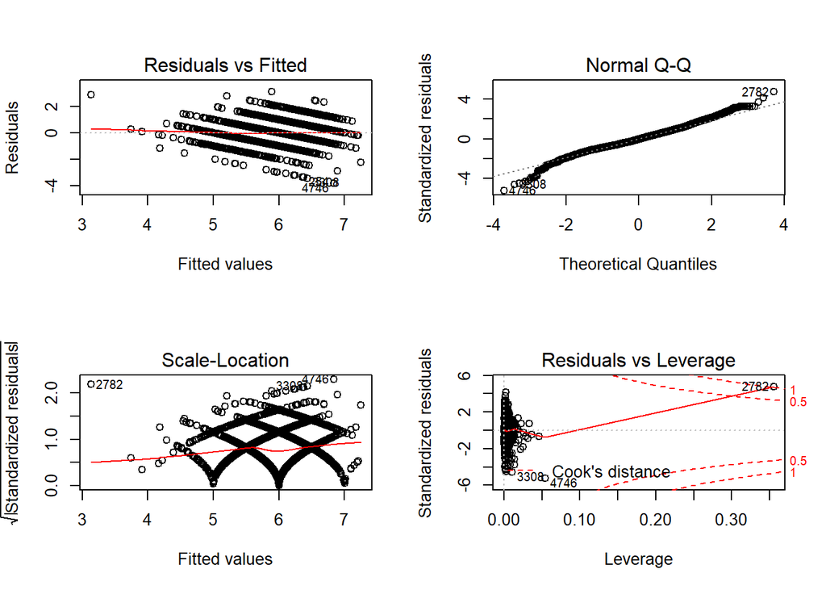

Looking at the residuals plots there appears to be one outlier that could be effecting the output of the model so I am going to remove that datapoint and re-run the model.

```
##
## Calls:
## m1: lm(formula = quality ~ alcohol, data = wqw.new)
## m2: lm(formula = quality ~ alcohol + density, data = wqw.new)
## m5: lm(formula = quality ~ alcohol + density + residual.sugar + chlorides +
##     sulphates, data = wqw.new)
## m7: lm(formula = quality ~ alcohol + density + residual.sugar + chlorides +
##     sulphates + pH + fixed.acidity + volatile.acidity, data = wqw.new)
## m9: lm(formula = quality ~ alcohol + density + residual.sugar + chlorides +
##     sulphates + pH + fixed.acidity + volatile.acidity + citric.acid +
##     free.sulfur.dioxide, data = wqw.new)
## m10: lm(formula = quality ~ alcohol + density + residual.sugar + chlorides +
##     sulphates + pH + fixed.acidity + volatile.acidity + citric.acid +
##     free.sulfur.dioxide + total.sulfur.dioxide, data = wqw.new)
##
## ============================================================================================================
##                              m1            m2            m5            m7            m9           m10
## ------------------------------------------------------------------------------------------------------------
##   (Intercept)               2.582***    -27.042***    121.165***    212.207***    211.030***    211.424***
##                            (0.098)       (6.608)      (13.972)      (21.975)      (21.978)      (22.737)
##   alcohol                   0.314***      0.369***      0.196***      0.112***      0.119***      0.119***
##                            (0.009)       (0.015)       (0.020)       (0.029)       (0.029)       (0.029)
##   density                                29.213***   -118.763***   -212.821***   -211.794***   -212.194***
##                                          (6.516)      (13.921)      (22.268)      (22.271)      (23.040)
##   residual.sugar                                        0.064***      0.105***      0.101***      0.101***
##                                                        (0.005)       (0.008)       (0.008)       (0.009)
##   chlorides                                            -1.736**       0.073        -0.080        -0.080
##                                                        (0.552)       (0.544)       (0.546)       (0.546)
##   sulphates                                             0.762***      0.734***      0.702***      0.702***
##                                                        (0.102)       (0.101)       (0.101)       (0.101)
##   pH                                                                  0.882***      0.869***      0.869***
##                                                                      (0.111)       (0.112)       (0.112)
##   fixed.acidity                                                       0.107***      0.111***      0.111***
##                                                                      (0.023)       (0.023)       (0.023)
##   volatile.acidity                                                   -1.939***     -1.874***     -1.875***
##                                                                      (0.109)       (0.111)       (0.114)
##   citric.acid                                                                       0.025         0.025
##                                                                                    (0.095)       (0.096)
##   free.sulfur.dioxide                                                               0.003***      0.003***
##                                                                                    (0.001)       (0.001)
##   total.sulfur.dioxide                                                                            0.000
##                                                                                                  (0.000)
## ------------------------------------------------------------------------------------------------------------
##   R-squared                 0.190         0.193         0.221         0.281         0.285         0.285
##   adj. R-squared            0.190         0.193         0.220         0.280         0.284         0.284
##   sigma                     0.797         0.796         0.782         0.752         0.750         0.750
##   F                      1146.259       585.416       277.220       239.085       194.942       177.184
##   p                         0.000         0.000         0.000         0.000         0.000         0.000
##   Log-likelihood        -5838.650     -5828.614     -5742.882     -5545.220     -5531.742     -5531.740
##   Deviance               3112.194      3099.464      2992.817      2760.709      2745.554      2745.551
##   AIC                   11683.300     11665.228     11499.764     11110.440     11087.484     11089.480
##   BIC                   11702.789     11691.214     11545.238     11175.404     11165.441     11173.933
##   N                      4897          4897          4897          4897          4897          4897
## ============================================================================================================
```

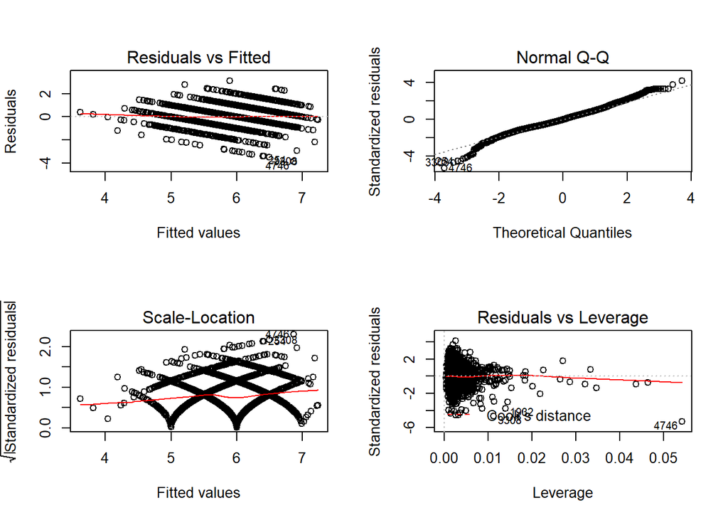

We got a very slight increase to the model but not very much and it looks like we got rid of all the major outliers.

As we can see even when taking into account every feature and removing the outlier the R-squared is still only 0.285 which is dismal at best and indicates that we can not make any predictions based on the data that we have.

(I had to remove some of the intermediary steps to make the model fit on the page.)

# Multivariate Analysis

### Talk about some of the relationships you observed in this part of the investigation. Were there features that strengthened each other in terms of looking at your feature(s) of interest?

All of the features that I investigated in this section show a dramatic lack of corelation. Even when combining features in different ways there was little to no interaction.

There were a few things that I discovered earlier that were confirmed but there wasn’t really anything new to explore.

### Were there any interesting or surprising interactions between features?

The only interesting thing was the complete lack of interesting interactions between features.

### OPTIONAL: Did you create any models with your dataset? Discuss the strengths and limitations of your model.

I did create a basic model and it was not able to predict anything. The main limitation of the model is that none of the features are corelated to the quality in any meaningful way.

# Final Plots and Summary

### Plot One

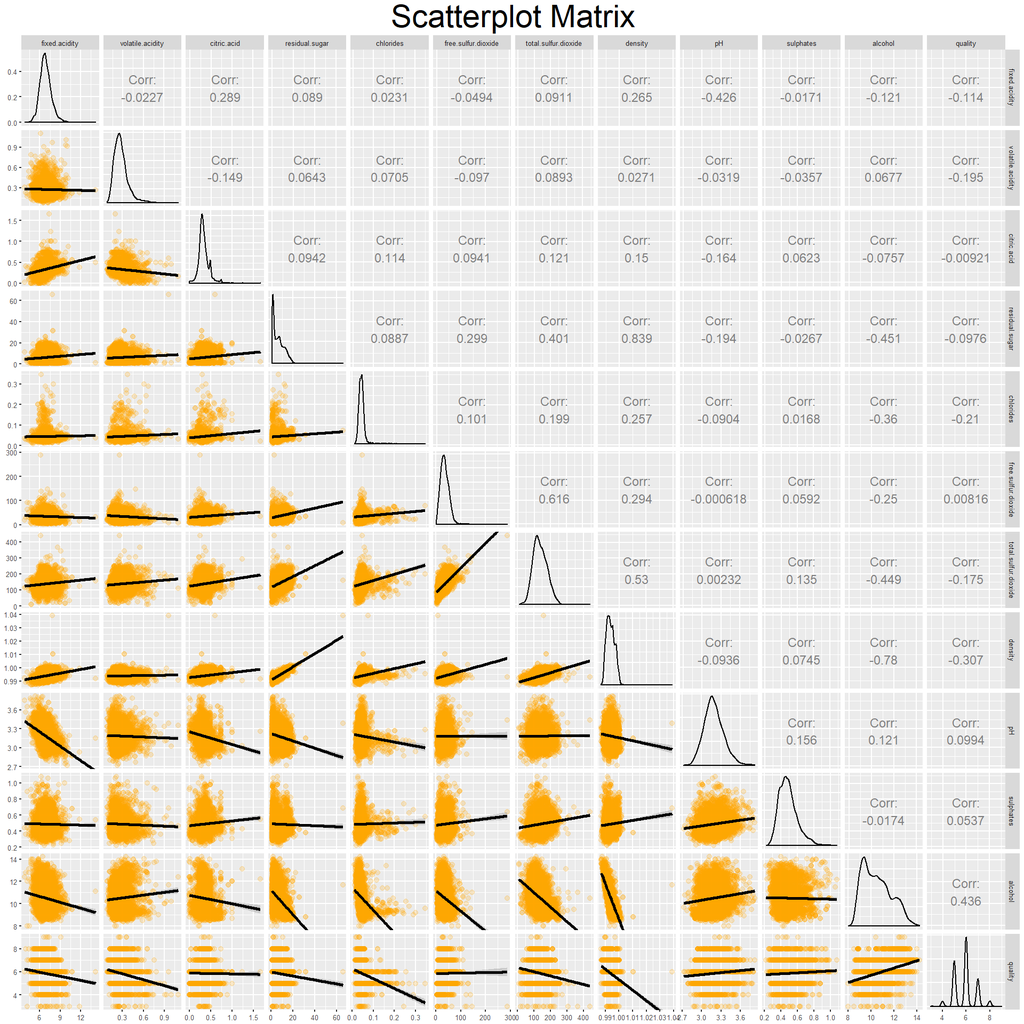

### Plot Two

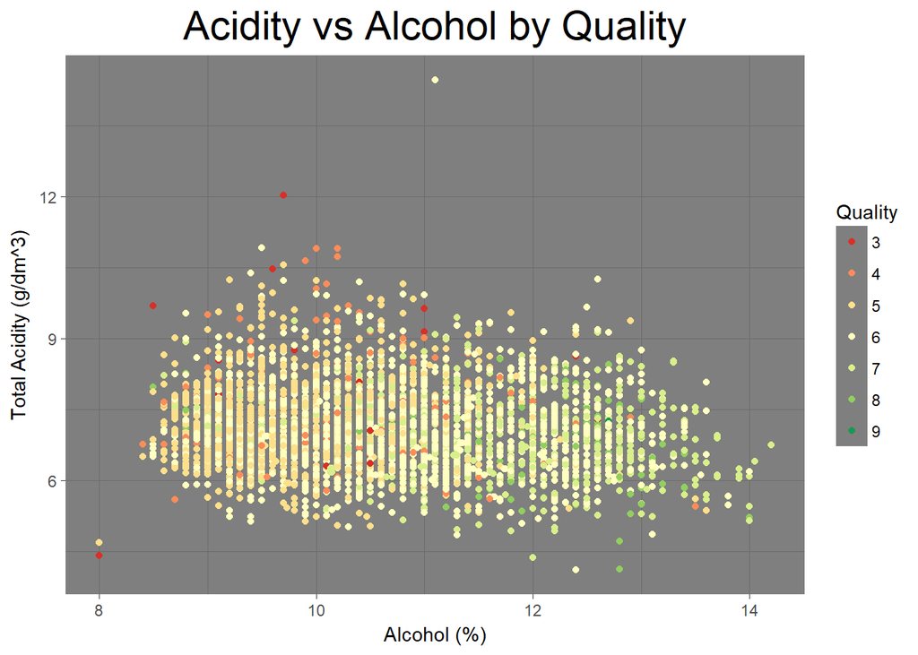

### Description Two

The only distiction I was able to discover was based on alcohol content and it is very slight at best. It does appear that a higher alcohol content increases the chance of a higher quality product but there is no clear distinction that can be seen. While the high quality products mostly have a higher alcohol content and low quality products have lower alcohol content the mid range products span the whole spectrum. Based on this it would be hard to determine the difference between a 6, 7, 8, or 9 quality based on the data provided. But you could probably tell the difference between a 4 and an 8.

### Plot Three

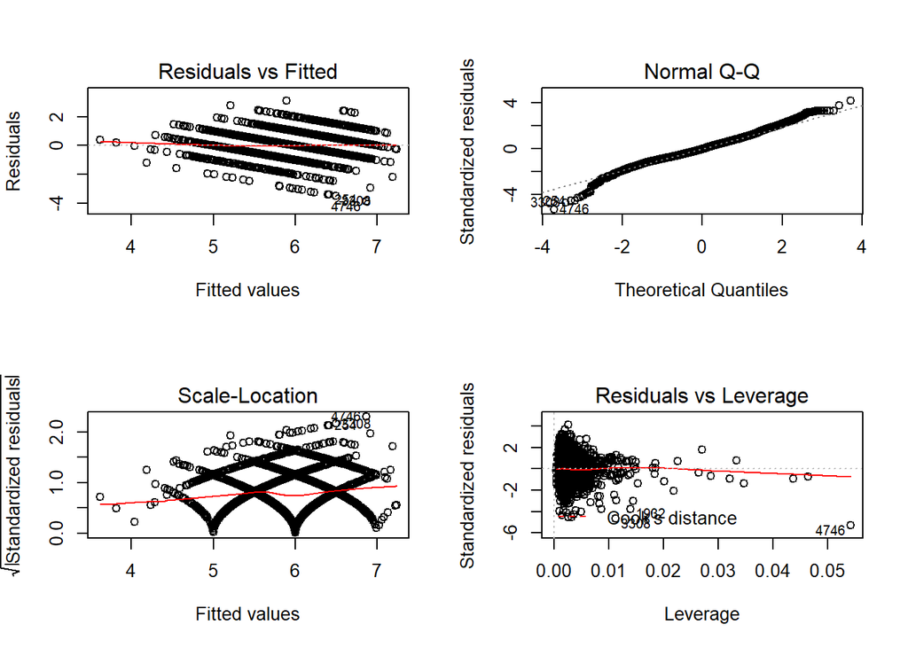

### Description Three

After some research it appears that the pattern shown in the Residuals vs. Fitted plot is most likely due to the fact that our dependent variable has only a few possible values. The patterns in the Scale-Location could indicate that a linear model is not the best for our data.

# Reflection

The Wine dataset that I used contained information from almost 5,000 wine tastings with their quality rating included. Initially I examined the data to see the shape of each of the features and then started exploring how they interact with each other. Then I compared the features against the quality to see if any of the features could help to predict the quality of the product. Finally I created a linear model to see if there was anything I missed in the data that could create predictions.

In the beginning I thought that the quality would have something to do with the alcohol, density, pH, and acidity. As I examined the data it became more and more clear that there was little to no correlation between any of the features and the quality. I found this suprising and really wanted to find any little thing that would point towards a corelation but nothing showed up. Finally when I created the linear model it was clear that you could not predict the quality of the wine from the data that we have in this dataset. We do see some small corelation between the alcohol content and the quality, it appears that the higher the alcohol content the more likely the wine will have a higher quality but there is definately not enough destinction to make any predictions.

I don’t know if more datapoints could make a difference but it seems at this point that the quality of wine is subjective and is difficult if not impossible to predict. I might be able to improve the models with more manipulation of the data but other models that I have seen max out at ~70% accuracy such as PennState’s STAT 897D Analysis of Wine Quality Data (https://onlinecourses.science.psu.edu/stat857/node/223/), and R-bloggers Predicting wine quality using Random Forests (https://www.r-bloggers.com/predicting-wine-quality-using-random-forests/) which use a lot more complex modeling than a basic linear model. R-bloggers use a random forest and acheived a 71.5% accuracy which is still very low for making predictions. They also had to modify the quality variable into groups where 3, 4, and 5 were considered low quality, 6 and 7 were medium, and 8 and 9 were high quality. I personally find this unacceptable as it degrades the quality of the output and artifically pushes the prediction rate higher. On a scale of 1-10 the difference between 8 and 9 can be quite substantial.